# Projekt

```r
# Wniosek: Nie widać zależności typu: im większe HDI, tym mniej chorób wirusowych.
```

6. Co jest skutkiem chorób wirusowych?

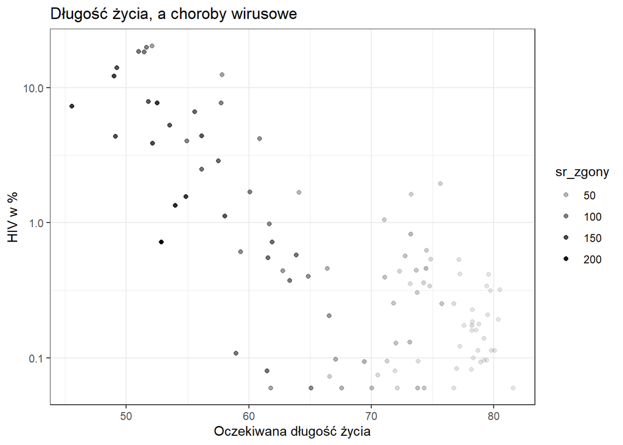

```r
# Zakładam, że w mojej ramce danych jedynymi skutkami może być większa liczba zgonów
# dzieci i krótsza długość życia.

skutki <- Choroby %>%
  group_by(country) %>%
  summarise(sr_dl_zycia = mean(dl_zycia),
            sr_HIV_procent = mean(HIV_procent),
            sr_zgony = mean(zgony_dzieci)) %>%
  ggplot(color = z) +
  geom_point(mapping = aes(y = sr_HIV_procent,
                           x = sr_dl_zycia,
                           alpha = sr_zgony)) +
  labs(title = "Długość życia, a choroby wirusowe",
       x = "Oczekiwana długość życia",
       y = "HIV w %") +
  theme_bw()

skutki + scale_y_continuous(trans='log10')
```

```r
# Wniosek: Skutkiem występowania chorób wirusowych jest krótsza długość życia oraz większa liczba zgonów.
```

7. Czy współczynnik zgonów na nowotwór okrężnicy/odbytnicy na świecie jest odwrotnie proporcjonalne do występowania HIV?

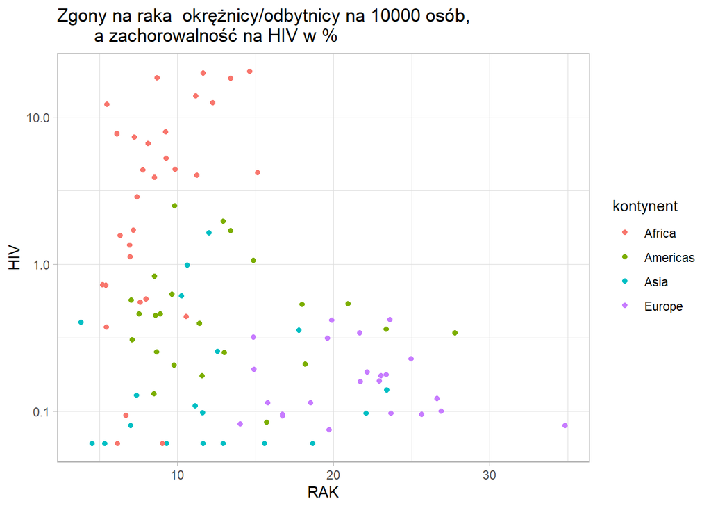

```r
HIVRAK <- Choroby %>%
  group_by(country, kontynent) %>%
  filter(kontynent != "Oceania") %>%
  summarise(HIV = mean(HIV_procent),
            RAK = (mean(rakna10000M) + mean(rakna10000W))/2) %>%
  ggplot(mapping = aes(y = HIV, x = RAK, col = kontynent)) +
  geom_point() +
  theme_light() +
  labs(title = "Zgony na raka  okrężnicy/odbytnicy na 10000 osób,
       a zachorowalność na HIV w %")
HIVRAK + scale_y_continuous(trans='log10')
```

```r
# Wniosek: Nie widać proporcjonalności odwrotnej jeśli patrzymy się na kontynenty.
# Jednakże można zauważyć, że kraje mające wysoki współczynnik zgonów na raka nie mają wysokiej zachorowalności na HIV.
```

8. Jak zmienia się występowanie chorób cywilizacyjnych na świecie i na poszczególnych kontynentach?

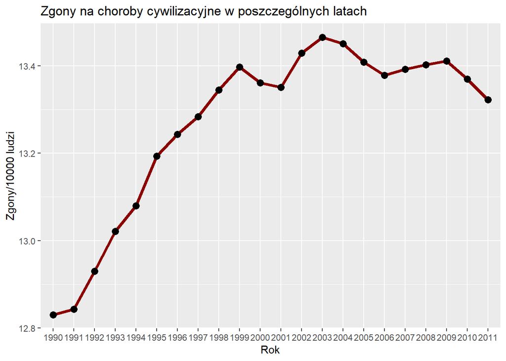

```r
HIVCYWOvr <- Choroby %>%
  group_by(rok) %>%
  summarise(RM = mean(rakna10000M),
            RW = mean(rakna10000W),
            HIVSR = mean(HIV_procent)) %>%
  mutate(CYW = (RM+RW)/2) %>%
  ggplot(aes(x=rok, y = CYW)) +
  geom_line(color = "darkred",
            group = 1,
            size = 1.5) +
  geom_point(size = 3) +
  labs(title = "Zgony na choroby cywilizacyjne w poszczególnych latach",
       x = "Rok",
       y = "Zgony/10000 ludzi")
HIVCYWOvr
```

```r
HIVCYWOvr2 <- Choroby %>%
  filter(kontynent != "Oceania") %>%
  group_by(rok,kontynent) %>%
  summarise(RM = mean(rakna10000M),
            RW = mean(rakna10000W),
            HIVSR = mean(HIV_procent)) %>%
  mutate(CYW = (RM+RW)/2) %>%
  select(rok,kontynent,CYW) %>%
  ggplot(aes(x=rok, y = CYW, col = kontynent, group = kontynent)) +
  geom_line(size = 1.5) +
  geom_point(size = 3) +
  labs(title = "Zgony na choroby cywilizacyjne w poszczególnych latach",
       x = "Rok",
       y = "Zgony/10000 ludzi") +
  theme(axis.text.x = element_text(face = "bold",
                                   size = 8,
                                   angle = 90))
```

[output not shown]

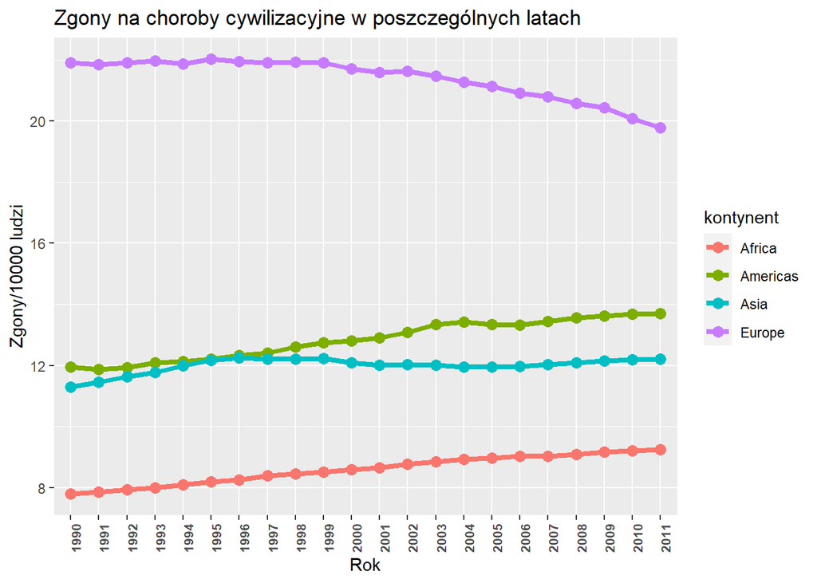

```r
HIVCYWOvr2
```

```r
# Wniosek: Zgony na choroby cywilizacyjne wszędzie rosną, tylko nie w Europie. Jest to spowodowane prawdopodobnie tym, że kontynent Europejski jest na tyle dobrze rozwinięty, przez co ludzie mają większą świadomość co może prowadzić do rozwoju nowotworów oraz społeczeństwo coraz częściej bada się na choroby nowotworowe, co pozwala wykryć je we wczesnym stanie zwiększąc szanse na przeżycie.

# Wniosek nr 2: Afryka, która przodowała w zachorowalności na choroby wirusowe, jest na ostatnim miejscu w zgonach na choroby cywilizacyjne, a Europa, która była ostatnia, przoduje w występowaniu zgonów na choroby cywilizacyjnych.
```

9. Jakie są różnice w zgonach na rak odbytnicy/okrężnicy w zależności od płci?

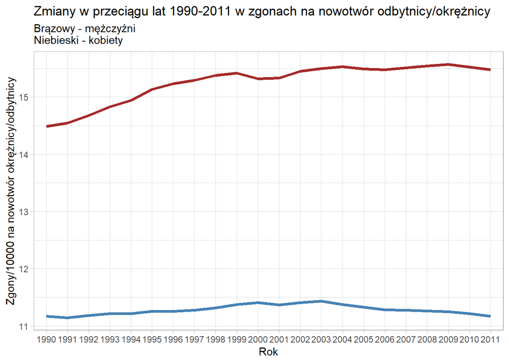

```r
Choroby %>%
  group_by(rok) %>%
  summarise(ŚR_RakM = mean(rakna10000M),
            ŚR_RakW = mean(rakna10000W)) %>%
  ggplot(aes(x = rok)) +
  geom_line(aes(y = ŚR_RakM),
            color = "brown",
            group = 1,
            size = 1.4) +
  geom_line(aes(y = ŚR_RakW),
            color = "steelblue",
            group = 1,
            size = 1.4) +
  labs(title = "Zmiany w przeciągu lat 1990-2011 w zgonach na nowotwór odbytnicy/okrężnicy",
       subtitle = "Brązowy - mężczyźni \nNiebieski - kobiety",
       x = "Rok" ,
       y = "Zgony/10000 na nowotwór okrężnicy/odbytnicy") +
  theme_light()
```

```r
#Wnioski: Mężczyżni umierają częściej na nowotwór odbytnicy, współczynnik zgonów u mężczyzn rośnie, a u kobiet jest na stałym poziomie.

KontynentyMW <- Choroby %>%
  group_by(kontynent) %>%
  summarise(ŚR_RakM = mean(rakna10000M),
            ŚR_RakW = mean(rakna10000W),
            "RakK/RakW * 100%" = (ŚR_RakW / ŚR_RakM)*100) %>%
  filter(kontynent != "Oceania")
KontynentyMW
```

```
## # A tibble: 4 × 4
##   kontynent ŚR_RakM ŚR_RakW `RakK/RakW * 100%`
##   <chr>       <dbl>   <dbl>              <dbl>
## 1 Africa       9.87    7.32               74.2
## 2 Americas    13.6    12.1                89.1
## 3 Asia        13.7    10.3                75.6
## 4 Europe      25.9    16.9                65.0
```

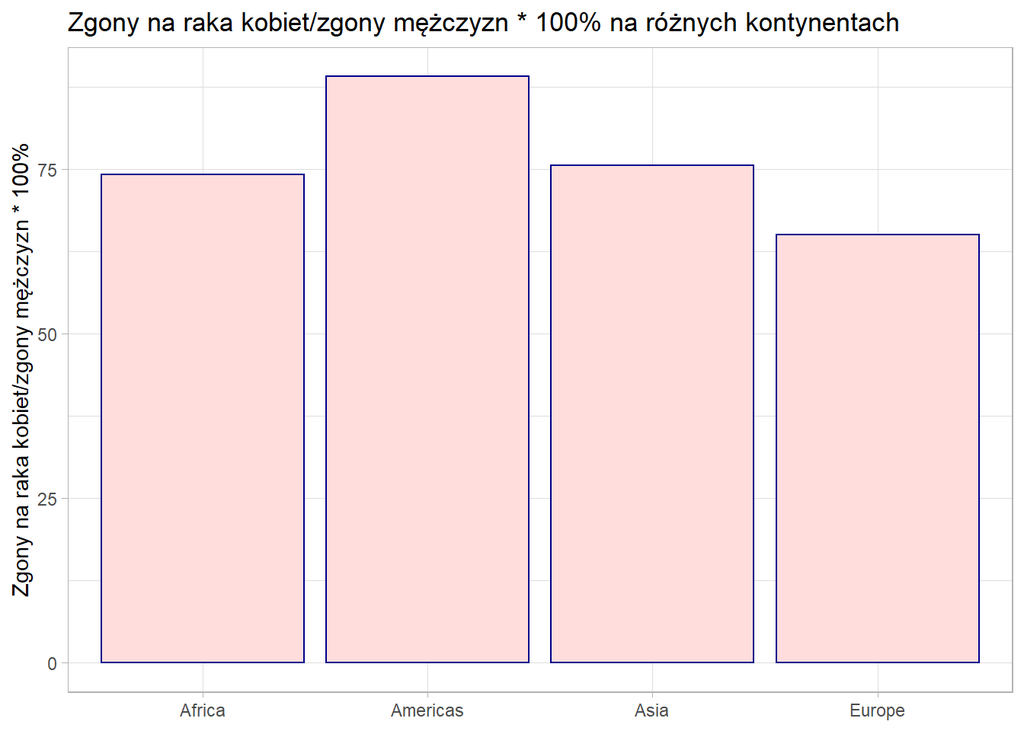

```r
ggplot(KontynentyMW,
       aes(y = KontynentyMW$`RakK/RakW * 100%`,
                         x = kontynent)) +
  geom_col(fill = "#FFDDDD",
           color = "darkblue") +
  labs(title = "Zgony na raka kobiet/zgony mężczyzn * 100% na różnych kontynentach",
       x = NULL,
       y = "Zgony na raka kobiet/zgony mężczyzn * 100%") +
  theme_light()
```

```r
# Wnioski: Największy współczynnik zgonów na nowotwór okrężnicy (kobiety/mężczyźni) występuje w Ameryce, a najmniejszy w Europie
```

Zatem można stwierdzić, że przyczyną występowania chorób wirusowych NIE jest niskie HDI i wysoki procentowy wzrost ludności (choć faktem jest, że występowanie choroby HIV jest największe w państwach afrykańskich, a na tym kontynencie HDI jest najmniejsze), gdyż nie widać żadnej zależności w państwach Afryki, które to zostały dotknięte epidemią. Mogła zostać ona wywołana niskim poziomem świadomości społeczeństwa o chorobie (w tym przypadku wyznacznikiem niskiej świadomości był poziom szczepień). Skutkiem chorób wirusowych jest wyższy współczynnik zgonów dzieci oraz niższa oczekiwana długość życia. Nie widać proporcjonalności odwrotnej patrząc się na kontynenty jeśli chodzi o występowanie HIV, a choroby cywilizacyjne. Niemal wszędzie współczynnik zgonów rośnie. Jednakże widać, że od pewnego momentu rozwoju cywilizacji zaczyna maleć (widać to na kontynencie Europejskim), gdyż (tutaj moje przypuszczenia) społeczeństwo ma większą świadomość o chorobie.